# Course Project

ahs

December 14, 2014

# Project Goal

The goal of this project is to determine how well people perform a particular exercise. I have no idea why all these errors/warnings are popping up here, so sorry.

# Exploration

The first step is to figure out what columns to use or not. We start with about 160 columns, which is a lot. I found that many columns weren’t well populated, so I went through and removed those. To do this, I kept a data structure of which columns had good values for use in cleaning the test data.

Now we have 60 columns of data.

Looking at the data, I thought it might be helpful to have a notion of where in the window the sample was taken, so I generated a t2_delta column to account for this. I haven’t yet evaluated if this was at all meaningful.

After building a classification tree that over-relied on the character columns of user name and such, I removed those, then built a new model.

```
## n= 19622
##
## node), split, n, loss, yval, (yprob)
##       * denotes terminal node
##
##  1) root 19622 14042 A (0.28 0.19 0.17 0.16 0.18)
##    2) roll_belt< 130.5 17977 12411 A (0.31 0.21 0.19 0.18 0.11)
##      4) pitch_forearm< -33.95 1578    10 A (0.99 0.0063 0 0 0) *
##      5) pitch_forearm>=-33.95 16399 12401 A (0.24 0.23 0.21 0.2 0.12)
##       10) magnet_dumbbell_y< 439.5 13870  9953 A (0.28 0.18 0.24 0.19 0.11)
##         20) roll_forearm< 123.5 8643  5131 A (0.41 0.18 0.18 0.17 0.061) *
##         21) roll_forearm>=123.5 5227  3500 C (0.077 0.18 0.33 0.23 0.18) *
##       11) magnet_dumbbell_y>=439.5 2529  1243 B (0.032 0.51 0.043 0.22 0.19) *
##    3) roll_belt>=130.5 1645    14 E (0.0085 0 0 0 0.99) *
```

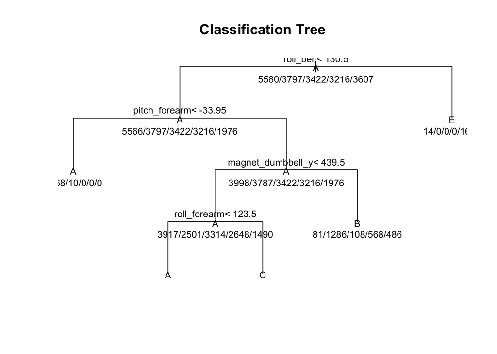

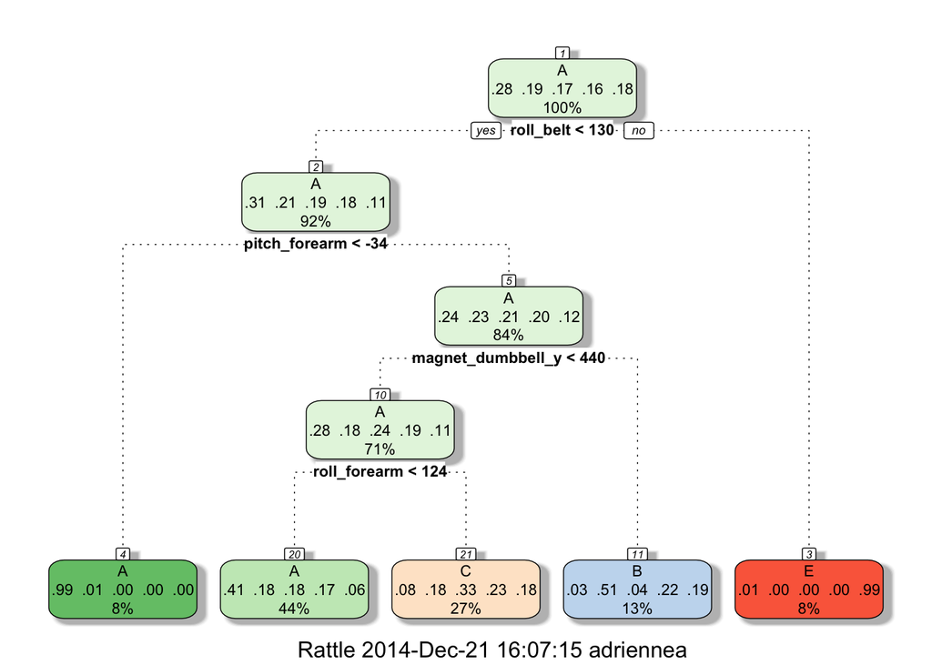

This looks more interesting than previous, so I’m going with this for now.

Now, let’s generate a random forest. Because it was taking so long to build, I created a new subset of train data to train faster.

```r
in_small_train <- createDataPartition(y=train_data$classe,p=0.2, list=FALSE)
small_td <- train_data[in_small_train,]

#modFit_rf <- train(classe~.,data=small_td,method="rf",prox=TRUE)
#save(modFit_rf, file="myRandomForest.RData")

load(file="myRandomForest.RData")
```

Evaluating the result on the small set of data we trained with:

[output not shown]

[output cut: 19 more lines]

```
##
## pred_train    A    B    C    D    E
##          A 1116    0    0    0    0
##          B    0  760    0    0    0
##          C    0    0  685    0    0
##          D    0    0    0  644    0
##          E    0    0    0    0  722
```

That looks good, so I’m going to apply it to the entire training set:

```
##
## pred_train2    A    B    C    D    E
##           A 5579    0    0    0    0
##           B    1 3797    0    0    0
##           C    0    0 3422    0    0
##           D    0    0    0 3216    0
##           E    0    0    0    0 3607
```

Since that looks good too, I’m going to go ahead and apply that to the test data. I created a function using my saved columns above to apply to the test data.

```r
clean_test_data <- function(data){

  data <- data[keep_cols]
  data <- data[keep_cols_2]

  # Get rid of X column
  data <- data[2:60]


  # Add the time diff column (t2_delta)
  data <- group_by(data, num_window) %>% mutate(t2_delta =
                                                  c(0,diff(raw_timestamp_part_2)))

   data$win_ind <- ave(data$new_window=="yes", FUN = function(x) {
            cumsum(x) })

  # Get rid of other cols
  data <- data[6:61]


  # Remove win_ind col

}
```

# Testing

Clearly, something is wrong with my model because I predict that everything is A.

```
##  [1] A A A A A A A A A A A A A A A A A A A A
## Levels: A B C D E
```